# FEM Cancer Statistics

Some analyses to spark off collaboration with other FEM models in Europe (and Bryan of course!).

# 1 Setup

## 1.1 Libraries

# 2 DATA

## 2.1 Starting Populations

```r
stock <- read_dta('input_data/ELSA_stock.dta')
repl <- read_dta('input_data/ELSA_repl.dta')
trans <- read_dta('input_data/ELSA_transition.dta')
```

## 2.2 Output

```r
base <- read_dta('output/COMPLETE/ELSA_core_base/ELSA_core_base_summary.dta')
cohort <- read_dta('output/COMPLETE/ELSA_core_cohort/ELSA_core_cohort_summary.dta')
```

## 2.3 Estimates and Projections

```r
estimates <- read.csv('FEM_R/Sep24/Eng_midyearEstimates_2011_2021.csv')
projections <- read.csv('FEM_R/Sep24/Eng_pop_proj_2018base.csv')
```

# 3 Combine Estimates and Projections

First need to combine the midyear estimates with the population projections for England and format them into something we can work with.

## 3.1 MidYear Estimates

```r
# Remove commas and convert population columns to numeric
est <- estimates %>%
  mutate(across(starts_with("population_"), ~as.numeric(gsub(",", "", .))))

# Create age groups (e.g., 50-59, 60-69, etc.)
est <- est %>%
  mutate(age_group = cut(age,
                         breaks = c(seq(50, 90, by = 10), Inf),  # Add Inf for 90+
                         include.lowest = TRUE,
                         right = FALSE,
                         labels = c("50-59", "60-69", "70-79", "80-89", "90+")))

# Sum by age group and sex using the new syntax for across()
est_by_sex <- est %>%
  group_by(sex, age_group) %>%
  summarise(across(starts_with("population_"), ~sum(.x, na.rm = TRUE)), .groups = "drop")

# Sum by age group for both sexes combined
est_total <- est %>%
  group_by(age_group) %>%
  summarise(across(starts_with("population_"), ~sum(.x, na.rm = TRUE)), .groups = "drop")

# View the results by sex
print(est_by_sex)
```

```
## # A tibble: 10 × 14
##    sex   age_group population_2011 population_2012 population_2013
##    <chr> <fct>               <dbl>           <dbl>           <dbl>
##  1 F     50-59             3242308         3320403         3403157
##  2 F     60-69             2925300         2967425         2992168
##  3 F     70-79             1988177         2004975         2047405
##  4 F     80-89             1242453         1244494         1243029
##  5 F     90+                302611          316473          322286
##  6 M     50-59             3183772         3260548         3338040
##  7 M     60-69             2794611         2833708         2856874
##  8 M     70-79             1724705         1748062         1794639
##  9 M     80-89              802298          822057          837509
## 10 M     90+                111803          121014          126718
## # ℹ 9 more variables: population_2014 <dbl>, population_2015 <dbl>,
## #   population_2016 <dbl>, population_2017 <dbl>, population_2018 <dbl>,
## #   population_2019 <dbl>, population_2020 <dbl>, population_2021 <dbl>,
## #   population_2022 <dbl>
```

```r
# View the results for both sexes combined
print(est_total)
```

```
## # A tibble: 5 × 13
##   age_group population_2011 population_2012 population_2013 population_2014
##   <fct>               <dbl>           <dbl>           <dbl>           <dbl>
## 1 50-59             6426080         6580951         6741197         6915923
## 2 60-69             5719911         5801133         5849042         5873807
## 3 70-79             3712882         3753037         3842044         3961749
## 4 80-89             2044751         2066551         2080538         2108558
## 5 90+                414414          437487          449004          468016
## # ℹ 8 more variables: population_2015 <dbl>, population_2016 <dbl>,
## #   population_2017 <dbl>, population_2018 <dbl>, population_2019 <dbl>,
## #   population_2020 <dbl>, population_2021 <dbl>, population_2022 <dbl>
```

```r
# Write the results to a CSV
write.csv(est_by_sex, "FEM_R/Sep24/Eng_midyearEstimates_by_sex.csv", row.names = FALSE)
write.csv(est_total, "FEM_R/Sep24/Eng_midyearEstimates_total.csv", row.names = FALSE)

rm(est, estimates)
```

## 3.2 Population Projections

```r
# Function to clean column names and collapse age groups
collapse_age_groups <- function(df) {

  # First remove the All ages row as its going to be incorrect by the end of the function
  df <- df %>%
    filter(AGE.GROUP != 'All ages')

  # Convert the year columns to numeric (except AGE.GROUP)
  df <- df %>%
    mutate(across(-AGE.GROUP, ~ as.numeric(.)))  # Convert all but AGE.GROUP to numeric

  # Filter out rows where AGE.GROUP is below 50
  df_filtered <- df %>%
    filter(AGE.GROUP %in% c("50-54", "55-59", "60-64", "65-69", "70-74", "75-79", "80-84", "85-89", "90+", "All ages"))

  # Collapse age groups into 10-year intervals for ages 50+
  df_collapsed <- df_filtered %>%
    mutate(AGE.GROUP = case_when(
      AGE.GROUP %in% c("50-54", "55-59") ~ "50-59",
      AGE.GROUP %in% c("60-64", "65-69") ~ "60-69",
      AGE.GROUP %in% c("70-74", "75-79") ~ "70-79",
      AGE.GROUP %in% c("80-84", "85-89") ~ "80-89",
      TRUE ~ AGE.GROUP  # Keep other categories (e.g., "90+", "All ages") as they are
    )) %>%
    # Group by age group and sum across all years
    group_by(AGE.GROUP) %>%
    summarise(across(everything(), sum, na.rm = TRUE), .groups = "drop") %>%
    rename_with(~ gsub("^X", "population_", .x), starts_with("X")) %>%
    rename(age_group = AGE.GROUP)

  return(df_collapsed)
}


# Apply the function to your dataset
proj <- collapse_age_groups(projections)
rm(projections)
```

## 3.3 Combine

```r
# Give midyear estimates priority over projections in the case of overlapping data
proj_dropped <- proj %>%
  select(-population_2018, -population_2019, -population_2020, -population_2021, -population_2022)

# Now merge on age group column
combined_est_proj <- merge(est_total, proj_dropped, by = 'age_group')

# finally pivot df so rows == years, and we can fix the age_group colname and the prefixes whilst were at it
combined <- combined_est_proj %>%
  pivot_longer(cols = population_2011:population_2043, names_to = "year", values_to = "population") %>%
  pivot_wider(names_from = age_group, values_from = population) %>%
  mutate(year = gsub("population_", "", year)) %>%
  mutate(year = as.numeric(year))
```

Quick plot to check that this data looks reasonable.

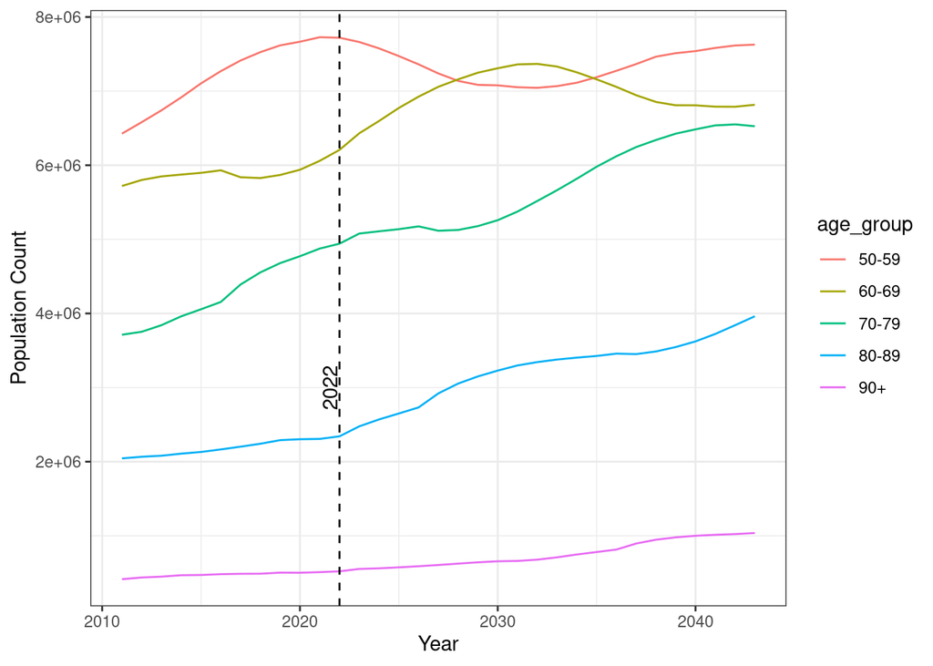

```r
# First pivot then plot
combined_plot <- combined %>%
  pivot_longer(cols = `50-59`:`90+`,
               names_to = 'age_group',
               values_to = 'population_count')

ggplot(combined_plot, aes(x = year, y = population_count, group = age_group, colour = age_group)) +
  geom_line() +
  geom_vline(xintercept = 2022, linetype = 'dashed') +
  annotate("text", x = 2021.5, y = 3000000, label = "2022", angle = 90) +
  xlab('Year') +
  ylab('Population Count')
```

```r
# geom_label(aes(2022, 1.2), label = '2022', show.legend = FALSE) +
```

Looks alright. The dashed line at 2022 is to show the cross-over between midyear estimates and population projections.

# 4 Cancer Statistics

XXXX who runs the Irish FEM model would like us to produce some counts of individuals with cancer in specific age ranges. Check the email to see if he mentioned the specific age ranges (he doesn’t). Nik said 70+ so lets start there.

Therefore step 1 is to get the midyear estimates and projections for ages 70+ by aggregating some of the information in the combined_est_proj dataframe. After that, we can multiply the prevalence from our dataset for the 70+ population by these estimates/projected population counts.

```r
# First prepare the population counts dataset to keep just the 70+ population for all years to 2043
# drop the 5059 and 6069 columns, then sum the rest for 70+ age group
combined_70p <- combined %>%
  select(-`50-59`, -`60-69`) %>%
  mutate(pop_70p = `70-79` + `80-89` + `90+`) %>%
  select(year, pop_70p)

combined_70p
```

| year | pop_70p |
| --- | --- |
| 2011 | 6172047 |
| 2012 | 6257075 |
| 2013 | 6371586 |
| 2014 | 6538323 |
| 2015 | 6658908 |
| 2016 | 6802762 |
| 2017 | 7080809 |
| 2018 | 7284756 |
| 2019 | 7472456 |
| 2020 | 7576724 |

[output cut: 23 more lines]

```r
# Now get the FEM columns we need to compare
# To calculate the counts of cancer patients over the age of 70 at the national level,
#   we need the prevalence of cancer in this age group at each year.
#   We can then multiply the prevalence by the counts for that year (in the
#   combined_70p dataframe created above) to get the national level value
FEM_cancre <- base %>%
  select(year, p_cancre_70p)

# Now merge the 2 dataframes on year (keep only years in FEM dataset)
merged <- merge(x = FEM_cancre, y = combined_70p, by = 'year', all.x = TRUE, all.y = FALSE)

# Remove any years where population counts doesn't have any data
#   (at time of writing we have counts up to 2043)
merged <- merged[complete.cases(merged),]

# Last is to multiply the values together and plot results just for fun
merged$national_cancre <- round(merged$p_cancre_70p * merged$pop_70p)

merged
```

|  | year | p_cancre_70p | pop_70p | national_cancre |
| --- | --- | --- | --- | --- |
| 1 | 2012 | 0.1513063 | 6257075 | 946735 |
| 2 | 2014 | 0.1735410 | 6538323 | 1134667 |
| 3 | 2016 | 0.1856799 | 6802762 | 1263136 |
| 4 | 2018 | 0.1934329 | 7284756 | 1409112 |
| 5 | 2020 | 0.2028681 | 7576724 | 1537076 |
| 6 | 2022 | 0.2122969 | 7803990 | 1656763 |
| 7 | 2024 | 0.2188096 | 8239308 | 1802839 |
| 8 | 2026 | 0.2266137 | 8496127 | 1925338 |
| 9 | 2028 | 0.2342260 | 8805137 | 2062392 |
| 10 | 2030 | 0.2369544 | 9143372 | 2166562 |

[output cut: 6 more lines]

```r
# format counts to 1000s
merged_formatted <- merged %>%
  mutate(national_cancre = national_cancre / 1000000,
         pop_70p = pop_70p / 1000000)

merged_formatted
```

|  | year | p_cancre_70p | pop_70p | national_cancre |
| --- | --- | --- | --- | --- |
| 1 | 2012 | 0.1513063 | 6.257075 | 0.946735 |
| 2 | 2014 | 0.1735410 | 6.538323 | 1.134667 |
| 3 | 2016 | 0.1856799 | 6.802762 | 1.263136 |
| 4 | 2018 | 0.1934329 | 7.284756 | 1.409112 |
| 5 | 2020 | 0.2028681 | 7.576724 | 1.537076 |
| 6 | 2022 | 0.2122969 | 7.803990 | 1.656763 |
| 7 | 2024 | 0.2188096 | 8.239308 | 1.802839 |
| 8 | 2026 | 0.2266137 | 8.496127 | 1.925338 |
| 9 | 2028 | 0.2342260 | 8.805137 | 2.062392 |
| 10 | 2030 | 0.2369544 | 9.143372 | 2.166562 |

[output cut: 6 more lines]

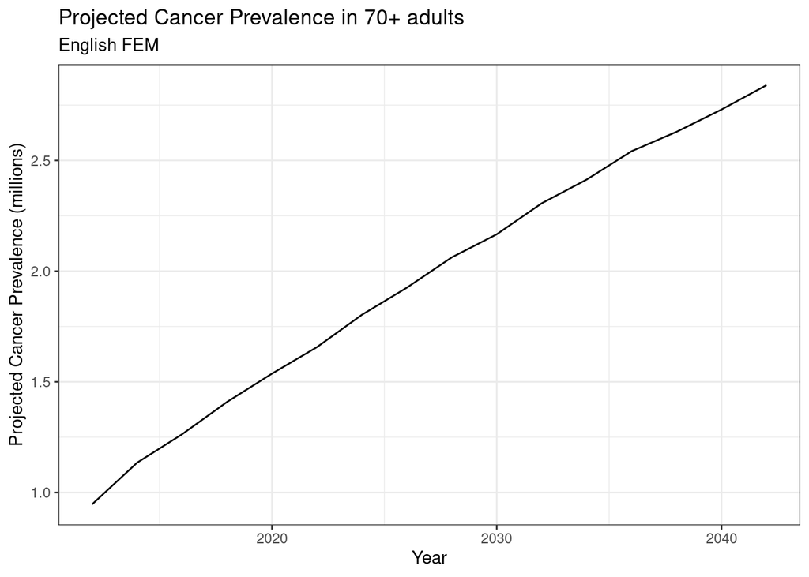

```r
ggplot(merged_formatted, aes(x = year, y = national_cancre)) +
  geom_line() +
  labs(title = "Projected Cancer Prevalence in 70+ adults",
       subtitle = 'English FEM') +
  xlab('Year') +
  ylab('Projected Cancer Prevalence (millions)')
```